# Factors Effecting Loan Outcome

## by Amer Jadid

## Investigation Overview

In this presentation, I will Explain the factors that effects the loan outcome status, including whether if the loan is more likely to default or not, where I'm going to answer the following questions:

1. Is the Borrower a Homeowner or not, and how does it effects the outcome?
2. Does the Borrower Have a Verified Income, does it affect the loan outcome?
3. What is the credit / Presper score of the Borrower and how does it affect the loan outcome.
4. How does interest Rate effects the behavior of the Borrower?
5. Does the Loan original amount effect the loan outcome?
6. Does the location of the borrower have a relation with the loan outcome?
7. What is the period where most Loans are being Defaulted? is there any exogenous effect that might explain the behavior?

## Dataset Overview

This data set used for presentation will only contains 113,066 loans with 22 variables on each loan, including loan amount, borrower rate (or interest rate), current loan status, borrower income, and many others.

## Count-Plot of the Loan Status

The Count for `Chargedoff & Defaulted` (15.05%) is almost `half` the count of `Completed` (33.66%) Loan Status, and about `half` of all `loans` are currently `in progress`. The rest of loan status are dropped as the sum of them represent less than 2% combined of the overall loans.

Loan Status Explanation:

- Chargedoff is a declaration by a creditor that an amount of debt is unlikely to be collected. This occurs when a consumer becomes severely delinquent on a debt
- Completed is when Loan have no more payments.
- A loan can have the status current when one or more payments have been completed and no payments are past due.\n It also means that this loan still has one or more scheduled future payments.
- Default is the failure to repay a debt on a loan.

For the rest of the visualizations I will consider only:

- Chargedoff + Defaulted Loan Status combined.
- Completed Loan Status.

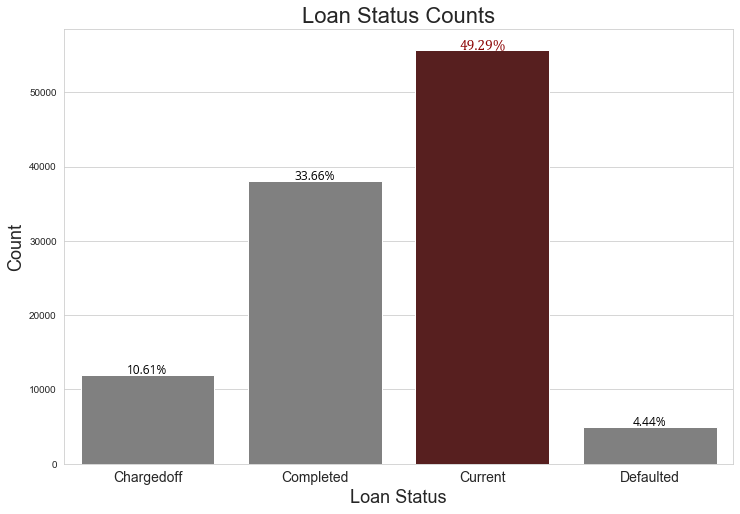

```python
#create a countplot for loan status
plt.figure(figsize = (12, 8))
cols = ['Chargedoff', 'Completed', 'Current', 'Defaulted']
values_list = df.LoanStatus.value_counts(sort = False).loc[cols].sort_index().values
normalized_values = np.round(df.LoanStatus.value_counts(sort=False, normalize=True).loc[cols].sort_index().values*100, 2)
sns.countplot(df.LoanStatus[df.LoanStatus.isin(cols)], palette = ['grey' if x < max(values_list) else '#601616' for x in values_list], order=cols)
locx, _ = plt.xticks(rotation=0, size = 14)
plt.xlabel('Loan Status', size = 18)
plt.ylabel('Count', size = 18)
plt.title('Loan Status Counts', size = 22)
for x, y, s in zip(locx, values_list, normalized_values):
        if y == max(values_list):
            plt.text(x, y+150, str(s) + '%', ha='center', fontsize=14, color='darkred', fontname = 'Cambria')
        else:
            plt.text(x, y+150, str(s) + '%', ha='center', fontsize=12, color='k', fontname = 'Open Sans')
```

## Count of Loan Status Over Time

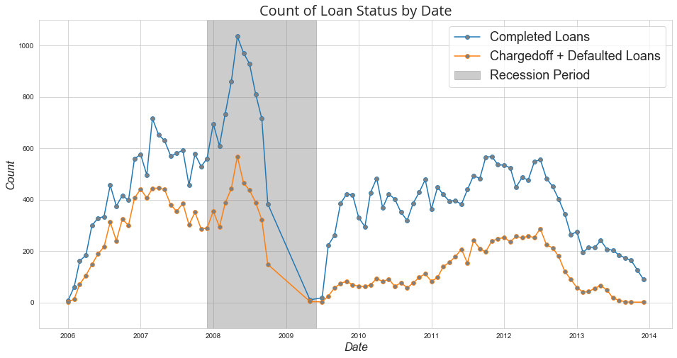

```python
#plot the change of loan status over time
plt.figure(figsize = (16, 8))
ax = sns.lineplot(data=completed, label = 'Completed Loans', marker = 'o', markerfacecolor = 'grey', markeredgecolor = None)
sns.lineplot(data=default, ax = ax, label = 'Chargedoff + Defaulted Loans', marker = 'o', markerfacecolor = 'grey', markeredgecolor = None)
ax.fill_betweenx(y = [-100, 1100], x1 = pd.to_datetime('2007-12-01'), x2 = pd.to_datetime('2009-06-01'), color = 'grey', alpha = 0.4, label = 'Recession Period')
ax.set_xlabel('Date', style='italic', size = 16)
ax.set_ylabel('Count', style='italic', size = 16)
ax.set_title('Count of Loan Status by Date', style='italic', size = 20, fontname = 'Open Sans')
ax.set_ylim([-100, 1100])
plt.legend(fontsize = 18);
```

## Brrower Interest Rate by Stated Monthly Income, Monthly Loan Payment, & Loan Original Amount

There is an interaction effect visible between Stated Monthly Income, Monthly Loan Payment, & Loan Original Amount. The 3 variables have a high correlation between each other, where the increase of interest rate decreases the monthly income, monthly loan payments and loan original amount. The borrower tend to borrow less when the interest rate increase, which leads to a less monthly payments associated with the size of the loan, but also the decrease in stated monthly income when interest rate increase, can be explained that the borrower tend to borrow less when he/she have a lower monthly income. In other words, borrower tend to borrow less when his/her monthly income is smaller and/or interest rate is higher.

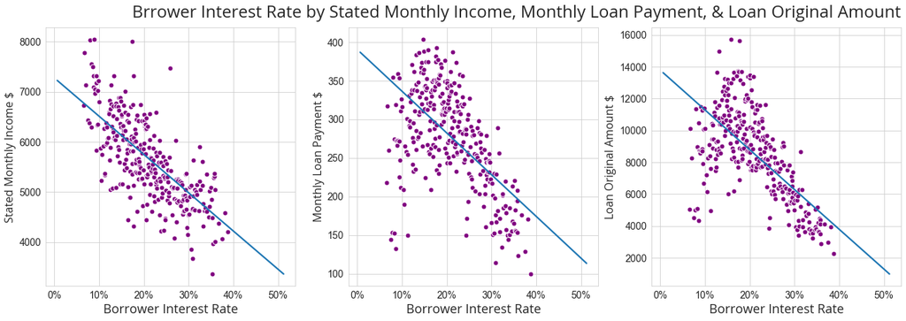

```python
figure, ax = plt.subplots(1, 3, figsize=(18, 6))

x_vars = ['StatedMonthlyIncome', 'MonthlyLoanPayment', 'LoanOriginalAmount']
x_labels = ['Stated Monthly Income \u0024', 'Monthly Loan Payment \u0024', 'Loan Original Amount \u0024']
#Scatter BorrowerAPR vs. Mean of Stated Monthly Income binned by BorrowerAPR
for i, y, label, in zip(range(3), x_vars, x_labels):
    sns.regplot(x = 'BorrowerAPR', y = y,
                      x_estimator=np.mean, x_bins=int(np.sqrt(len(df))),
                      ci=None, data = df,scatter_kws=dict(edgecolor = 'w', color ='purple') ,ax = ax[i])

    ax[i].set_xlabel('Borrower Interest Rate', style='italic', size = 18, fontname = 'Open Sans')
    ax[i].set_xticks([0, 0.1, 0.2, 0.3, 0.4, 0.5])
    ax[i].set_xticklabels(['0%', '10%', '20%', '30%', '40%', '50%'], size = 14)

    ax[i].set_ylabel(label, style='italic', size = 16, fontname = 'Open Sans')
    ax[i].tick_params(axis='y', which='major', labelsize=14)

plt.suptitle('Brrower Interest Rate by Stated Monthly Income, Monthly Loan Payment, & Loan Original Amount', y = 1.05, x = .57, style='italic', size = 24, fontname = 'Open Sans', ha = 'center')
plt.tight_layout();
```

## Loan Status by Interest Rate for Is Borrower Homeowner and Income Verifiable

We can clearly see the how Interest Rate with Borrower home ownership and Income Verifiable is effecting the loan status, where the median interest rate for a homeowner is lower than the median interest rate for completed loans compared charged-off loans, and the same goes for the income verifiable where the median interest rate for income verifiable is lower than non-income verifiable and lower median interest rate for completed loans compared charged-off loans.

In other words, the loan is considered a to be at lower risk of being defaulted or charge-off for the Lender, if the Borrower is a homeowner and/or the borrower have a verifiable income, where those borrowers tend to borrow at lower interest rate.

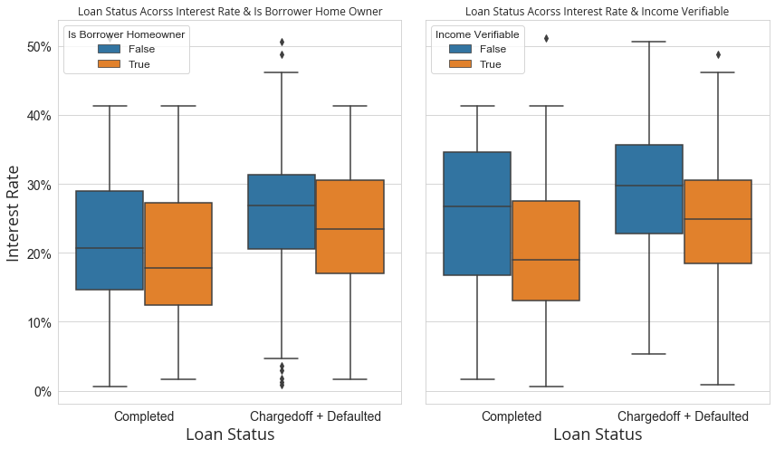

```python
figure, ax = plt.subplots(1, 2, figsize=(12, 7))


num_var = 'BorrowerAPR'
cat_var = ['LoanStatusNew']*2
hues = ['IsBorrowerHomeowner', 'IncomeVerifiable']
labels = ['Is Borrower Homeowner', 'Income Verifiable']
titles = ['Loan Status Acorss Interest Rate & Is Borrower Home Owner', 'Loan Status Acorss Interest Rate & Income Verifiable']

for i, cat, hue, label, title in zip(range(2), cat_var, hues, labels, titles):
    ax[i] = sns.boxplot(y = num_var, x = cat,hue = hue,
                 data = data, ax = ax[i])
    ax[i].set_title(title, style='italic', size = 12, fontname = 'Open Sans')
    ax[i].set_xlabel('Loan Status', style='italic', size = 18, fontname = 'Open Sans')
    ax[i].tick_params(axis='x', which='major', labelsize=14)
    ax[i].legend(title = label, fontsize = 12, title_fontsize = 12)

ax[0].set_yticks([0, 0.1, 0.2, 0.3, 0.4, 0.5])
ax[0].set_yticklabels(['0%', '10%', '20%', '30%', '40%', '50%'], size = 14)
ax[1].set_yticklabels('')
ax[0].set_ylabel('Interest Rate', style='italic', size = 18, fontname = 'Open Sans')
ax[1].set_ylabel('')

plt.tight_layout();
```

## Loan Status by Interest Rate for Credit Grade and Prosper Score

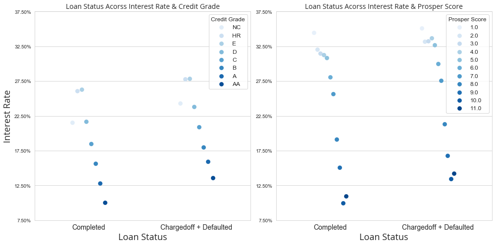

```python
figure, ax = plt.subplots(1, 2, figsize=(14, 7))


num_var = 'BorrowerAPR'
hues = ['CreditGrade', 'ProsperScore']
cat_var = ['LoanStatusNew']*2
labels = ['Credit Grade', 'Prosper Score']
titles = ['Loan Status Acorss Interest Rate & Credit Grade', 'Loan Status Acorss Interest Rate & Prosper Score']

for i, cat, hue, label, title in zip(range(2), cat_var, hues, labels, titles):
    ax[i] = sns.pointplot(y = num_var, x = cat,hue = hue,
                 data = data, join = False, dodge = 0.3, ci = False, ax = ax[i], palette='Blues')
    ax[i].set_title(title, style='italic', size = 14, fontname = 'Open Sans')
    ax[i].set_xlabel('Loan Status', style='italic', size = 18, fontname = 'Open Sans')
    ax[i].tick_params(axis='x', which='major', labelsize=14)
    ax[i].legend(title = label, fontsize = 12, title_fontsize = 12)
    ax[i].set_yticks(np.arange(0.075, 0.4, 0.05))
    ax[i].set_yticklabels(['{:.2f}%'.format(x) for x in np.arange(0.075, 0.4, 0.05)*100])

ax[0].set_ylabel('Interest Rate', style='italic', size = 18, fontname = 'Open Sans')
ax[1].set_ylabel('')

plt.tight_layout();
```

## Choropleth Map for High Risk Loans

In the Choropleth Map we can see states with high risk loans such as Lowe and Maine, where more than 35% of loans is being defaulted or charged-off. Also, there are states with low default tendency like Wyoming and Arkansans with less than 10% of loans being defaulted or charged-off. In other words, I will be more cautious in lending borrowers from states with high tendency to default.

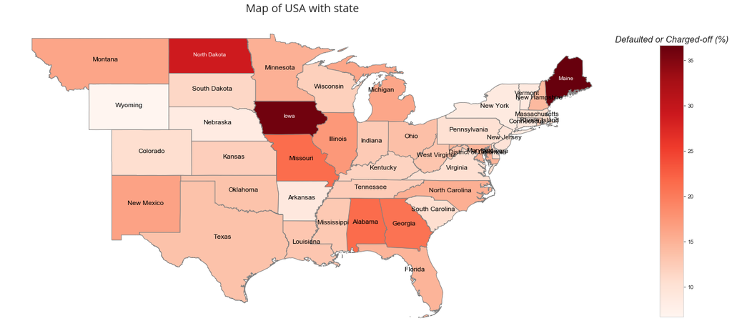

```python
#actual plotting
ax = gpd.plotting.plot_dataframe(defaultmap, figsize = (20, 17.5), cmap = 'Reds', edgecolor = 'grey', column = 'Defaulted', legend = False, vmin=min(defaultmap.Defaulted), vmax=max(defaultmap.Defaulted))
plt.suptitle('Map of USA with state', y = .75, style='italic', size = 20, fontname = 'Open Sans')
defaultmap.apply(lambda x: ax.annotate(s=x.NAME, xy=x.geometry.centroid.coords[0], ha='center', color = 'k', size = 12) if (x.Defaulted < 25) else ax.annotate(s=x.NAME, xy=x.geometry.centroid.coords[0], ha='center', color = 'w', size = 10) ,axis=1)

# add a color bar
fig = ax.get_figure()
cbax = fig.add_axes([0.95, 0.3, 0.03, 0.39])
cbax.set_title('Defaulted or Charged-off (%)', style='italic', size = 16)

colormap = "Reds"
sm = plt.cm.ScalarMappable(cmap=colormap, norm=plt.Normalize(vmin=min(defaultmap.Defaulted), vmax=max(defaultmap.Defaulted)))

# blank-out the array of the scalar mappable 'sm'
sm._A = []
# draw colorbar into 'cbax'
fig.colorbar(sm, cax=cbax, format="%d")
ax.set_axis_off();
```